# Predict How Well an Activity was Performed

## Synopsis

Using devices such as Jawbone UP, Nike FuelBand and Fitbit is now possible to collection a large amount of data about personal activity relatively inexpensively. One thing that people regularly do is quantity how much of a particular activity they do, but they rarely quantify how well they do it. In this project, we will use data from accelerometers on the belt, forearm, arm, and dumbbell of 6 young health participants. They were asked to perform barbell lifts correctly and incorrectly in 5 different ways. Our goal is to build a machine learning algorithm to predict activity quality.

## Getting and processing data

The Weight Lifting Exercises Data for this project come from [this source] (http://groupware.les.inf.puc-rio.br/har). We download the training data pml-training.csv and the test data [pml-tesing.csv] (https://d396qusza40orc.cloudfront.net/predmachlearn/pml-testing.csv) , and use RStudio to read these two raw csv files. The original training data WleTrain have 19622 observations and 160 variables.

```r
wleTrain<-read.csv("pml-training.csv")
wleTest<-read.csv("pml-testing.csv")
dim(wleTrain)
```

```
## [1] 19622   160
```

```r
dim(wleTest)
```

```
## [1]  20 160
```

We find that many columns contain missing values and summarizing information such as maximum values and average values. These variables are not supposed to be good predictors, so we subset the wleTrain data and wleTest data to get rid of them. The resulting subsets have 59 variables.

```r
wleTrain<-subset(wleTrain, select=c(user_name:total_accel_belt,gyros_belt_x:total_accel_arm,gyros_arm_x:magnet_arm_z,roll_dumbbell:yaw_dumbbell,total_accel_dumbbell,gyros_dumbbell_x:yaw_forearm,total_accel_forearm,gyros_forearm_x:classe))
wleTest<-subset(wleTest, select=c(user_name:total_accel_belt,gyros_belt_x:total_accel_arm,gyros_arm_x:magnet_arm_z,roll_dumbbell:yaw_dumbbell,total_accel_dumbbell,gyros_dumbbell_x:yaw_forearm,total_accel_forearm,gyros_forearm_x:problem_id))
wleTest<-transform(wleTest,magnet_dumbbell_z=as.numeric(magnet_dumbbell_z), magnet_forearm_y=as.numeric(magnet_forearm_y),magnet_forearm_z=as.numeric(magnet_forearm_z))
dim(wleTrain)
```

```
## [1] 19622    59
```

```r
dim(wleTest)
```

```
## [1] 20 59
```

## Fitting models

Out goal is to fit a model with the variable classe as the outcome. Classe is a factor variable with 5 levels of A,B,C,D, and E in which A means exactly according to the specification, B means throwing the elbows to the front, C means lifting the dumbbell only halfway, D means lowering the dumbbell only halfway, E means throwing the hips to the front. The regression models are not appropriate for multi-class categorical outcomes. We will use tree-based methods to predict the classe variable to find out how well a human activity was performed.

First we want to create another testing set to estimate the out of sample error of the fitted model. We run a 70% 30% Split on the wleTrain data to get the training data and testing data.

```r
library(caret)
set.seed(2008)
inTrain = createDataPartition(wleTrain$classe, p = .7,list=FALSE)
training = wleTrain[ inTrain,]
testing = wleTrain[-inTrain,]
dim(training)
```

```
## [1] 13737    59
```

The image below shows some patterns between the outcome and predictors.

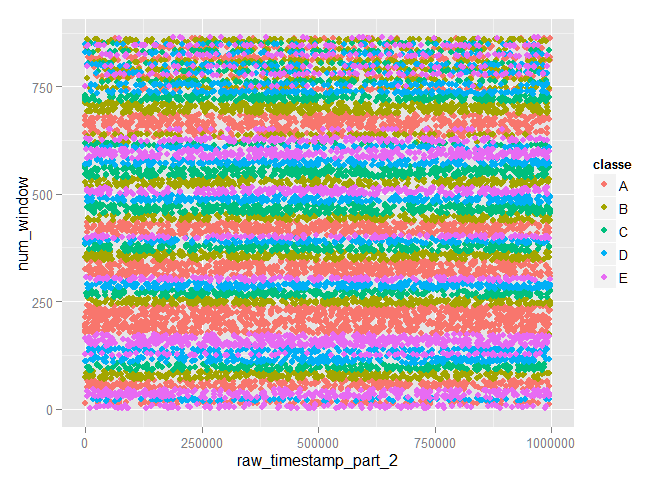

```r
library(ggplot2)
qplot(raw_timestamp_part_2, num_window, col=classe, data=training)
```

We use Principal Components Analysis (PCA) to reduce the number of predictors and then fit a random forest model using PCA with principal components explaining 95% of the variance in the predictors.

```r
# Do PCA on numerical variables.
pre<-preProcess(training[,-c(1,4,5,59)],method="pca",thresh=0.95)
pre
```

```
##
## Call:
## preProcess.default(x = training[, -c(1, 4, 5, 59)], method = "pca",
##  thresh = 0.95)
##
## Created from 13737 samples and 55 variables
## Pre-processing: principal component signal extraction, scaled, centered
##
## PCA needed 26 components to capture 95 percent of the variance
```

```r
trainPC<-predict(pre,training[,-c(1,4,5,59)])
trainPC2<-cbind(trainPC,training[,c(1,4,5,59)])
library(randomForest)
set.seed(2008)
pcamodel<-randomForest(classe~.,data=trainPC2,ntree=300)
pcamodel
```

```
##
## Call:
##  randomForest(formula = classe ~ ., data = trainPC2, ntree = 300)
##                Type of random forest: classification
##                      Number of trees: 300
## No. of variables tried at each split: 5
##
##         OOB estimate of  error rate: 1.62%
## Confusion matrix:
##      A    B    C    D    E class.error
## A 3882   15    9    0    0    0.006144
## B   37 2600   21    0    0    0.021821
## C    1   33 2356    6    0    0.016694
## D    0    0   81 2166    5    0.038188
## E    0    0    1   14 2510    0.005941
```

The estimate of error rate is 1.62%. The mean this model with CPA is good.

We fit another random forest model using k-fold cross validation relating classe to the remaining variables as they are.

```r
set.seed(2008)
trainmodel<-train(classe~.,data=training,method="rf",trControl=trainControl(method="cv",number=5))
trainmodel
```

```
## Random Forest
##
## 13737 samples
##    58 predictor
##     5 classes: 'A', 'B', 'C', 'D', 'E'
##
## No pre-processing
## Resampling: Cross-Validated (5 fold)
##
## Summary of sample sizes: 10991, 10989, 10989, 10990, 10989
##
## Resampling results across tuning parameters:
##
##   mtry  Accuracy  Kappa  Accuracy SD  Kappa SD
##    2    1         1      3e-03        3e-03
##   41    1         1      7e-04        8e-04
##   80    1         1      1e-03        2e-03
##
## Accuracy was used to select the optimal model using  the largest value.
## The final value used for the model was mtry = 41.
```

The model with 5-fold cross validation has amazing accuracy rate nearly to 1. The estimate error rate is very close to 0. So PCA doesn’t improve the model accuracy. We choose the model without PCA and test it on the testing data.

```r
pred<-predict(trainmodel,testing)
confusionMatrix(pred,testing$classe)
```

```
## Confusion Matrix and Statistics
##
##           Reference
## Prediction    A    B    C    D    E
##          A 1674    0    0    0    0
##          B    0 1139    1    0    0
##          C    0    0 1020    0    0
##          D    0    0    5  963    0
##          E    0    0    0    1 1082
##
## Overall Statistics
##
##                Accuracy : 0.999
##                  95% CI : (0.998, 1)
##     No Information Rate : 0.284
##     P-Value [Acc > NIR] : <2e-16
##
##                   Kappa : 0.998
##  Mcnemar's Test P-Value : NA
##
## Statistics by Class:
##
##                      Class: A Class: B Class: C Class: D Class: E
## Sensitivity             1.000    1.000    0.994    0.999    1.000
## Specificity             1.000    1.000    1.000    0.999    1.000
## Pos Pred Value          1.000    0.999    1.000    0.995    0.999
## Neg Pred Value          1.000    1.000    0.999    1.000    1.000
## Prevalence              0.284    0.194    0.174    0.164    0.184
## Detection Rate          0.284    0.194    0.173    0.164    0.184
## Detection Prevalence    0.284    0.194    0.173    0.164    0.184
## Balanced Accuracy       1.000    1.000    0.997    0.999    1.000
```

The out of sample error of this model is 0.1% which is quite small. The model with 0.999 accuracy is a great fit.

## Predicting 20 different test cases.

```r
wleTest$classe<-factor(c("A","B","C","D","E"))
pred20<-predict(trainmodel, wleTest[,-59])
pred20
```

```
##  [1] B A B A A E D B A A B C B A E E A B B B
## Levels: A B C D E
```